# Homework_3

## d

- From the third model from the previous part, discuss whether the *odds* of men and women being wears of glasess/contact lenses for distance vision differs. Test whether the *proportion* of wearers of glasses/contact lenses for distance vision differs between men and women. Include the results of the test and its interpretation.

> From previous manipualtion, we can see that in this model the coefficient fitted value before predictor logicalRIAGENDR is -0.5162712, which means that setting all others the same, woman are more likely to wear glasses/contact lenses relative to men. Also, the coefficient fitted value has a p-value smaller than 0.05 (and close to 0 in the z-test), showing it is statistically significant. So we can say that the odds of men and women being wears of glasess/contact lenses for distance vision significantly differs.

> Then to test whether the proportion of wearers of glasses/contact lenses for distance vision differs between men and women we will use the chi-square test

```stata
. tabulate logicalRIAGENDR logicalVIQ220, chi2

logicalRIA |     logicalVIQ220
     GENDR |         0          1 |     Total
-----------+----------------------+----------
         0 |     1,673      1,521 |     3,194
         1 |     1,919      1,134 |     3,053
-----------+----------------------+----------
     Total |     3,592      2,655 |     6,247

          Pearson chi2(1) =  70.1108   Pr = 0.000
```

# Problem 2 Sakila

## a

- Aside from English, what language is most common for films? Answer this with a single SQL query.

```r
library(DBI)
sakila <- dbConnect(RSQLite::SQLite(), "sakila_master.db")
dbListTables(sakila)
```

```
##  [1] "actor"                  "address"                "category"
##  [4] "city"                   "country"                "customer"
##  [7] "customer_list"          "film"                   "film_actor"
## [10] "film_category"          "film_list"              "film_text"
## [13] "inventory"              "language"               "payment"
## [16] "rental"                 "sales_by_film_category" "sales_by_store"
## [19] "staff"                  "staff_list"             "store"
```

```r
dbListFields(sakila, "language")
```

```
## [1] "language_id" "name"        "last_update"
```

```r
dbGetQuery(sakila, "SELECT * FROM language LIMIT 1000")
```

```
##   language_id     name         last_update
## 1           1  English 2020-12-23 07:12:12
## 2           2  Italian 2020-12-23 07:12:12
## 3           3 Japanese 2020-12-23 07:12:12
## 4           4 Mandarin 2020-12-23 07:12:12
## 5           5   French 2020-12-23 07:12:12
## 6           6   German 2020-12-23 07:12:12
```

```r
dbGetQuery(sakila, "SELECT language_id, COUNT(language_id) AS `value_occurrence` FROM film GROUP BY language_id ORDER BY `value_occurrence` DESC")
```

```
##   language_id value_occurrence
## 1           1             1000
```

> From the results, we see that the most common language is English, and there are no more other languages in this dataset.

## b

- What genre of movie is the most common in the data, and how many movies are of this genre?

```r
dbGetQuery(sakila, "select * from category limit 100")
```

```
##    category_id        name         last_update
## 1            1      Action 2020-12-23 07:12:31
## 2            2   Animation 2020-12-23 07:12:31
## 3            3    Children 2020-12-23 07:12:31
## 4            4    Classics 2020-12-23 07:12:31
## 5            5      Comedy 2020-12-23 07:12:31
## 6            6 Documentary 2020-12-23 07:12:31
## 7            7       Drama 2020-12-23 07:12:31
## 8            8      Family 2020-12-23 07:12:31
## 9            9     Foreign 2020-12-23 07:12:31
## 10          10       Games 2020-12-23 07:12:31
## 11          11      Horror 2020-12-23 07:12:31
## 12          12       Music 2020-12-23 07:12:31
## 13          13         New 2020-12-23 07:12:31
## 14          14      Sci-Fi 2020-12-23 07:12:31
## 15          15      Sports 2020-12-23 07:12:31
## 16          16      Travel 2020-12-23 07:12:31
```

> First we extract the `category` table to know the corresponding categories of numbers.

**Using R to solve it**

```r
library(dplyr)
two_b_table<-dbGetQuery(sakila, "select * from film_category limit 1000")
two_b_table|>group_by(category_id)|>summarise(counts=n())|>arrange(desc(counts))
```

```
## # A tibble: 16 × 2
##    category_id counts
##          <int>  <int>
##  1          15     74
##  2           9     73
##  3           8     69
##  4           6     68
##  5           2     66
##  6           1     64
##  7          13     63
##  8           7     62
##  9          10     61
## 10          14     61
## 11           3     60
## 12           5     58
## 13           4     57
## 14          16     57
## 15          11     56
## 16          12     51
```

**Using SQL to solve it**

```r
head(dbGetQuery(sakila, "select * from film_category limit 1000"))
```

```
##   film_id category_id         last_update
## 1       1           6 2020-12-23 07:14:58
## 2       2          11 2020-12-23 07:14:58
## 3       3           6 2020-12-23 07:14:58
## 4       4          11 2020-12-23 07:14:58
## 5       5           8 2020-12-23 07:14:58
## 6       6           9 2020-12-23 07:14:58
```

```r
dbGetQuery(sakila, "SELECT category_id, COUNT(category_id) AS `value_occurrence` FROM film_category GROUP BY category_id ORDER BY `value_occurrence` DESC")
```

```
##    category_id value_occurrence
## 1           15               74
## 2            9               73
## 3            8               69
## 4            6               68
## 5            2               66
## 6            1               64
## 7           13               63
## 8            7               62
## 9           10               61
## 10          14               61
## 11           3               60
## 12           5               58
## 13           4               57
## 14          16               57
## 15          11               56
## 16          12               51
```

> From the data we can know that the most common film type is `Sports`, and it counts for 74 movies in total.

## c

- Identify which country or countries have exactly 9 customers.

**Using R to solve it**

```r
two_c_table<-dbGetQuery(sakila, "select * from customer_list limit 1000")
two_c_table|>group_by(country)|>summarise(counts=n())|>arrange(desc(counts))|>filter(counts=="9")
```

```
## # A tibble: 1 × 2
##   country        counts
##   <chr>           <int>
## 1 United Kingdom      9
```

> The country with exactly 9 customers is the United Kingdom.

**Using SQL to solve it**

```r
d5 <- dbGetQuery(sakila,"
SELECT country FROM (
  SELECT COUNT(ctm.customer_id) AS count, ctry.country AS country FROM customer ctm LEFT JOIN address a ON ctm.address_id = a.address_id LEFT JOIN city ct ON a.city_id = ct.city_id LEFT JOIN country ctry ON ct.country_id = ctry.country_id GROUP BY ctry.country) WHERE count = 9
")
d5
```

```
##          country
## 1 United Kingdom
```

> From the result we can see that the country has exactly 9 customers is the U.K., which is the same as calculated before.

# Problem 3 US Records

## a

- What proportion of email addresses are hosted at a domain with TLD “.net”? (E.g. in the email, “angrycat@freemail.org”, “freemail.org” is the domain, with TLD (top-level domain) “.org”.)

```r
the_table<-read.csv("us-500.csv")
library(tidyverse)
head(the_table)
```

```
##   first_name last_name           company_name              address        city
## 1      James      Butt      Benton, John B Jr   6649 N Blue Gum St New Orleans
## 2  Josephine   Darakjy  Chanay, Jeffrey A Esq  4 B Blue Ridge Blvd    Brighton
## 3        Art    Venere    Chemel, James L Cpa 8 W Cerritos Ave #54  Bridgeport
## 4      Lenna  Paprocki Feltz Printing Service          639 Main St   Anchorage
## 5    Donette    Foller    Printing Dimensions         34 Center St    Hamilton
## 6     Simona   Morasca    Chapman, Ross E Esq         3 Mcauley Dr     Ashland
##       county state   zip       phone1       phone2
## 1    Orleans    LA 70116 504-621-8927 504-845-1427
## 2 Livingston    MI 48116 810-292-9388 810-374-9840
## 3 Gloucester    NJ  8014 856-636-8749 856-264-4130
## 4  Anchorage    AK 99501 907-385-4412 907-921-2010
## 5     Butler    OH 45011 513-570-1893 513-549-4561
## 6    Ashland    OH 44805 419-503-2484 419-800-6759
##                           email                                 web
## 1               jbutt@gmail.com        http://www.bentonjohnbjr.com
## 2 josephine_darakjy@darakjy.org    http://www.chanayjeffreyaesq.com
## 3                art@venere.org      http://www.chemeljameslcpa.com
## 4         lpaprocki@hotmail.com http://www.feltzprintingservice.com
## 5        donette.foller@cox.net   http://www.printingdimensions.com
## 6            simona@morasca.com      http://www.chapmanrosseesq.com
```

```r
grepl(".net",the_table$email)|>sum(na.rm=TRUE)
```

```
## [1] 73
```

```r
grepl(".net",the_table$email)|>sum(na.rm=TRUE)/nrow(the_table)
```

```
## [1] 0.146
```

> There are 73 addresses hosted at a domain with TLD “net”, and thus the proportion would be 73/500=0.146

## b

- What proportion of email addresses have at least one non alphanumeric character in them?

```r
grepl("[^a-zA-Z0-9@.]",the_table$email)|>sum(na.rm=TRUE)
```

```
## [1] 124
```

```r
grepl("[^a-zA-Z0-9@.]",the_table$email)|>sum(na.rm=TRUE)/nrow(the_table)
```

```
## [1] 0.248
```

> There are 124 email address containing at least one non-alphanumeric character, and thus the proportion would be 124/500=0.248

## c

- What is the most common area code amongst all phone numbers?

```r
the_table_2<-the_table%>%
  mutate(area_code_1=substr(the_table$phone1, 1, 3))%>%
  mutate(area_code_2=substr(the_table$phone2, 1, 3))

the_table_2%>%
  group_by (area_code_1)|>summarize(counts=n())|>arrange(desc(counts))
```

```
## # A tibble: 161 × 2
##    area_code_1 counts
##    <chr>        <int>
##  1 973             18
##  2 212             14
##  3 215             14
##  4 410             14
##  5 201             12
##  6 305              9
##  7 310              8
##  8 718              8
##  9 419              7
## 10 508              7
## # ℹ 151 more rows
```

```r
the_table_2%>%
  group_by (area_code_2)|>summarize(counts=n())|>arrange(desc(counts))
```

```
## # A tibble: 161 × 2
##    area_code_2 counts
##    <chr>        <int>
##  1 973             18
##  2 212             14
##  3 215             14
##  4 410             14
##  5 201             12
##  6 305              9
##  7 310              8
##  8 718              8
##  9 419              7
## 10 508              7
## # ℹ 151 more rows
```

> From the result we can see that the most common area code is 973.

> We can also notice that even there are two columns for phone, each household has the same area code for their phones since their addresses are fixed, so count on `area_code_1` or `area_code_2` would yield the same results.

## d

- Produce a histogram of the log of the apartment numbers for all addresses. (You may assume any number after the street is an apartment number.)

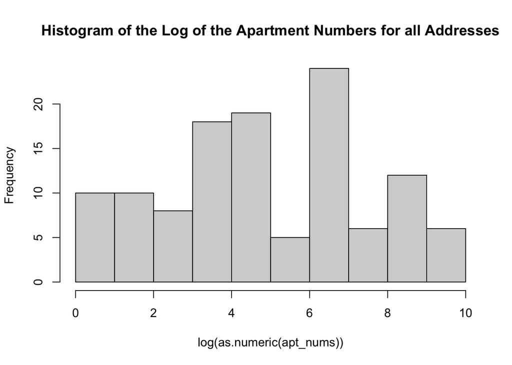

```r
apt_nums <- regmatches(the_table$address, regexpr("[1234567890]+$", the_table$address))

hist(log(as.numeric(apt_nums)),main="Histogram of the Log of the Apartment Numbers for all Addresses")
```

> The Benford’s law states that in many real-life sets of numerical data, the leading digit is likely to be small. In sets that obey the law, the number 1 appears as the leading significant digit about 30% of the time, while 9 appears as the leading significant digit less than 5% of the time.

```r
library(BenfordTests)
chisq.benftest(as.numeric(apt_nums))
```

```
##
##  Chi-Square Test for Benford Distribution
##
## data:  as.numeric(apt_nums)
## chisq = 52.84, p-value = 1.158e-08
```

> Then, with the specific function in R, we can test if it follows theBenford’s law. The p-value is extremely small, indicating that there is a significant difference between the observed data and the Benford distribution, so apartment numbers can not pass as real data.

## f

- Repeat your analysis of Benford’s law on the last digit of the street number.

```r
# just some notes, please do not grade them unlist(strsplit(the_table$address," ")){extract(the_table, "address", c("Streetname", "HouseNumber", "Apt"), "(\\D+)(\\d.*)(\\D+)")}
```

```r
#pattern <- "^(\\d+)\\s"
the_table_3 <- the_table %>%
   mutate(st_num =as.numeric(str_extract(address, "\\d+")))%>%
  mutate(last_digit = st_num %% 10)
```

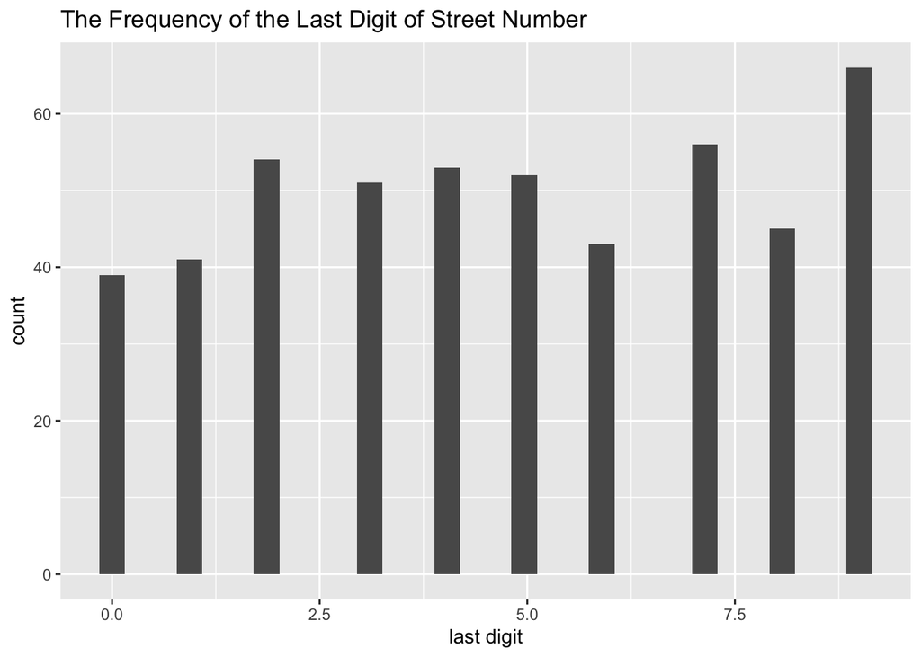

```r
ggplot(the_table_3, aes(x = last_digit))+geom_histogram()+xlab("last digit")+ggtitle("The Frequency of the Last Digit of Street Number")
```

> From Wikipedia, the logarithm-histogram of Benford Law should be like

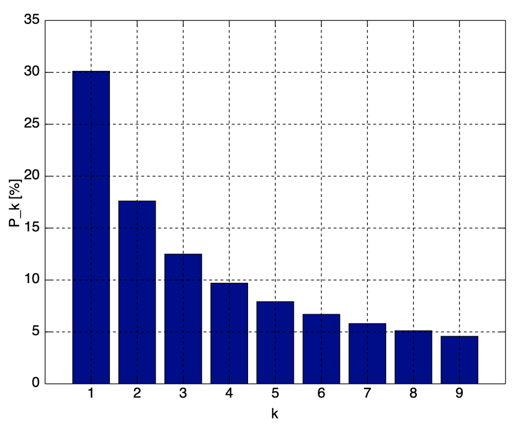

> Attribution: https://commons.wikimedia.org/wiki/File:Rozklad_benforda.svg

> Obviously it’s not similar to what we got from above. So I think the last digit of street number doesn’t follow the Benford law.

```r
chisq.benftest(the_table_3$last_digit)
```

```
##
##  Chi-Square Test for Benford Distribution
##
## data:  the_table_3$last_digit
## chisq = 223.16, p-value < 2.2e-16
```

> By using the function again, we can re-confirm that this time it also has a significant difference between the observed data and the Benford distribution.